# Risk Factor Analysis

## Outcome Variable

**Outcome Variable:** sstunted

## Predictor Variables

**Intervention Variable:** birthlen

**Adjustment Set:**

unadjusted

## Stratifying Variables

The analysis was stratified on these variable(s):

- agecat
- studyid
- country

## Data Summary

| agecat | studyid | country | birthlen | sstunted | n_cell | n |
| --- | --- | --- | --- | --- | --- | --- |
| Birth | ki0047075b-MAL-ED | BANGLADESH | >=50 cm | 0 | 39 | 231 |
| Birth | ki0047075b-MAL-ED | BANGLADESH | >=50 cm | 1 | 0 | 231 |
| Birth | ki0047075b-MAL-ED | BANGLADESH | <48 cm | 0 | 104 | 231 |
| Birth | ki0047075b-MAL-ED | BANGLADESH | <48 cm | 1 | 9 | 231 |
| Birth | ki0047075b-MAL-ED | BANGLADESH | [48-50) cm | 0 | 79 | 231 |
| Birth | ki0047075b-MAL-ED | BANGLADESH | [48-50) cm | 1 | 0 | 231 |
| Birth | ki0047075b-MAL-ED | BRAZIL | >=50 cm | 0 | 30 | 65 |
| Birth | ki0047075b-MAL-ED | BRAZIL | >=50 cm | 1 | 0 | 65 |
| Birth | ki0047075b-MAL-ED | BRAZIL | <48 cm | 0 | 14 | 65 |
| Birth | ki0047075b-MAL-ED | BRAZIL | <48 cm | 1 | 3 | 65 |
| Birth | ki0047075b-MAL-ED | BRAZIL | [48-50) cm | 0 | 18 | 65 |
| Birth | ki0047075b-MAL-ED | BRAZIL | [48-50) cm | 1 | 0 | 65 |
| Birth | ki0047075b-MAL-ED | INDIA | >=50 cm | 0 | 9 | 47 |
| Birth | ki0047075b-MAL-ED | INDIA | >=50 cm | 1 | 0 | 47 |
| Birth | ki0047075b-MAL-ED | INDIA | <48 cm | 0 | 18 | 47 |
| Birth | ki0047075b-MAL-ED | INDIA | <48 cm | 1 | 2 | 47 |
| Birth | ki0047075b-MAL-ED | INDIA | [48-50) cm | 0 | 18 | 47 |
| Birth | ki0047075b-MAL-ED | INDIA | [48-50) cm | 1 | 0 | 47 |
| Birth | ki0047075b-MAL-ED | NEPAL | >=50 cm | 0 | 8 | 27 |
| Birth | ki0047075b-MAL-ED | NEPAL | >=50 cm | 1 | 0 | 27 |
| Birth | ki0047075b-MAL-ED | NEPAL | <48 cm | 0 | 11 | 27 |
| Birth | ki0047075b-MAL-ED | NEPAL | <48 cm | 1 | 1 | 27 |
| Birth | ki0047075b-MAL-ED | NEPAL | [48-50) cm | 0 | 7 | 27 |
| Birth | ki0047075b-MAL-ED | NEPAL | [48-50) cm | 1 | 0 | 27 |
| Birth | ki0047075b-MAL-ED | PERU | >=50 cm | 0 | 52 | 233 |
| Birth | ki0047075b-MAL-ED | PERU | >=50 cm | 1 | 0 | 233 |
| Birth | ki0047075b-MAL-ED | PERU | <48 cm | 0 | 84 | 233 |
| Birth | ki0047075b-MAL-ED | PERU | <48 cm | 1 | 4 | 233 |
| Birth | ki0047075b-MAL-ED | PERU | [48-50) cm | 0 | 93 | 233 |
| Birth | ki0047075b-MAL-ED | PERU | [48-50) cm | 1 | 0 | 233 |

[output cut: 426 more lines]

The following strata were considered:

- agecat: 24 months, studyid: ki0047075b-MAL-ED, country: BANGLADESH
- agecat: 24 months, studyid: ki0047075b-MAL-ED, country: BRAZIL
- agecat: 24 months, studyid: ki0047075b-MAL-ED, country: INDIA
- agecat: 24 months, studyid: ki0047075b-MAL-ED, country: NEPAL
- agecat: 24 months, studyid: ki0047075b-MAL-ED, country: PERU
- agecat: 24 months, studyid: ki0047075b-MAL-ED, country: SOUTH AFRICA
- agecat: 24 months, studyid: ki0047075b-MAL-ED, country: TANZANIA, UNITED REPUBLIC OF
- agecat: 24 months, studyid: ki1000108-CMC-V-BCS-2002, country: INDIA
- agecat: 24 months, studyid: ki1000108-IRC, country: INDIA
- agecat: 24 months, studyid: ki1000109-EE, country: PAKISTAN
- agecat: 24 months, studyid: ki1017093-NIH-Birth, country: BANGLADESH
- agecat: 24 months, studyid: ki1017093b-PROVIDE, country: BANGLADESH
- agecat: 24 months, studyid: ki1017093c-NIH-Crypto, country: BANGLADESH
- agecat: 24 months, studyid: ki1101329-Keneba, country: GAMBIA
- agecat: 24 months, studyid: ki1113344-GMS-Nepal, country: NEPAL
- agecat: 24 months, studyid: ki1114097-CMIN, country: BANGLADESH
- agecat: 24 months, studyid: ki1114097-CONTENT, country: PERU
- agecat: 24 months, studyid: ki1119695-PROBIT, country: BELARUS
- agecat: 24 months, studyid: ki1126311-ZVITAMBO, country: ZIMBABWE
- agecat: 24 months, studyid: ki1135781-COHORTS, country: GUATEMALA
- agecat: 24 months, studyid: ki1135781-COHORTS, country: INDIA
- agecat: 24 months, studyid: ki1135781-COHORTS, country: PHILIPPINES
- agecat: 24 months, studyid: kiGH5241-JiVitA-3, country: BANGLADESH
- agecat: 24 months, studyid: kiGH5241-JiVitA-4, country: BANGLADESH
- agecat: 6 months, studyid: ki0047075b-MAL-ED, country: BANGLADESH
- agecat: 6 months, studyid: ki0047075b-MAL-ED, country: BRAZIL
- agecat: 6 months, studyid: ki0047075b-MAL-ED, country: INDIA
- agecat: 6 months, studyid: ki0047075b-MAL-ED, country: NEPAL
- agecat: 6 months, studyid: ki0047075b-MAL-ED, country: PERU
- agecat: 6 months, studyid: ki0047075b-MAL-ED, country: SOUTH AFRICA
- agecat: 6 months, studyid: ki0047075b-MAL-ED, country: TANZANIA, UNITED REPUBLIC OF
- agecat: 6 months, studyid: ki1000108-CMC-V-BCS-2002, country: INDIA
- agecat: 6 months, studyid: ki1000108-IRC, country: INDIA
- agecat: 6 months, studyid: ki1000109-EE, country: PAKISTAN
- agecat: 6 months, studyid: ki1000109-ResPak, country: PAKISTAN
- agecat: 6 months, studyid: ki1000304b-SAS-CompFeed, country: INDIA
- agecat: 6 months, studyid: ki1017093-NIH-Birth, country: BANGLADESH
- agecat: 6 months, studyid: ki1017093b-PROVIDE, country: BANGLADESH
- agecat: 6 months, studyid: ki1017093c-NIH-Crypto, country: BANGLADESH
- agecat: 6 months, studyid: ki1101329-Keneba, country: GAMBIA
- agecat: 6 months, studyid: ki1113344-GMS-Nepal, country: NEPAL
- agecat: 6 months, studyid: ki1114097-CMIN, country: BANGLADESH
- agecat: 6 months, studyid: ki1114097-CONTENT, country: PERU
- agecat: 6 months, studyid: ki1119695-PROBIT, country: BELARUS
- agecat: 6 months, studyid: ki1126311-ZVITAMBO, country: ZIMBABWE
- agecat: 6 months, studyid: ki1135781-COHORTS, country: GUATEMALA
- agecat: 6 months, studyid: ki1135781-COHORTS, country: INDIA
- agecat: 6 months, studyid: ki1135781-COHORTS, country: PHILIPPINES
- agecat: 6 months, studyid: kiGH5241-JiVitA-3, country: BANGLADESH
- agecat: 6 months, studyid: kiGH5241-JiVitA-4, country: BANGLADESH
- agecat: Birth, studyid: ki0047075b-MAL-ED, country: BANGLADESH
- agecat: Birth, studyid: ki0047075b-MAL-ED, country: BRAZIL
- agecat: Birth, studyid: ki0047075b-MAL-ED, country: INDIA
- agecat: Birth, studyid: ki0047075b-MAL-ED, country: NEPAL
- agecat: Birth, studyid: ki0047075b-MAL-ED, country: PERU
- agecat: Birth, studyid: ki0047075b-MAL-ED, country: SOUTH AFRICA
- agecat: Birth, studyid: ki0047075b-MAL-ED, country: TANZANIA, UNITED REPUBLIC OF
- agecat: Birth, studyid: ki1000108-CMC-V-BCS-2002, country: INDIA
- agecat: Birth, studyid: ki1000108-IRC, country: INDIA
- agecat: Birth, studyid: ki1000109-EE, country: PAKISTAN
- agecat: Birth, studyid: ki1000109-ResPak, country: PAKISTAN
- agecat: Birth, studyid: ki1000304b-SAS-CompFeed, country: INDIA
- agecat: Birth, studyid: ki1017093-NIH-Birth, country: BANGLADESH
- agecat: Birth, studyid: ki1017093b-PROVIDE, country: BANGLADESH
- agecat: Birth, studyid: ki1017093c-NIH-Crypto, country: BANGLADESH
- agecat: Birth, studyid: ki1101329-Keneba, country: GAMBIA
- agecat: Birth, studyid: ki1113344-GMS-Nepal, country: NEPAL
- agecat: Birth, studyid: ki1114097-CMIN, country: BANGLADESH
- agecat: Birth, studyid: ki1114097-CONTENT, country: PERU
- agecat: Birth, studyid: ki1119695-PROBIT, country: BELARUS
- agecat: Birth, studyid: ki1126311-ZVITAMBO, country: ZIMBABWE
- agecat: Birth, studyid: ki1135781-COHORTS, country: GUATEMALA
- agecat: Birth, studyid: ki1135781-COHORTS, country: INDIA
- agecat: Birth, studyid: ki1135781-COHORTS, country: PHILIPPINES
- agecat: Birth, studyid: kiGH5241-JiVitA-3, country: BANGLADESH
- agecat: Birth, studyid: kiGH5241-JiVitA-4, country: BANGLADESH

### Dropped Strata

Some strata were dropped due to rare outcomes:

- agecat: Birth, studyid: ki0047075b-MAL-ED, country: BANGLADESH
- agecat: Birth, studyid: ki0047075b-MAL-ED, country: BRAZIL
- agecat: Birth, studyid: ki0047075b-MAL-ED, country: INDIA
- agecat: Birth, studyid: ki0047075b-MAL-ED, country: NEPAL
- agecat: Birth, studyid: ki0047075b-MAL-ED, country: PERU
- agecat: Birth, studyid: ki0047075b-MAL-ED, country: SOUTH AFRICA
- agecat: Birth, studyid: ki0047075b-MAL-ED, country: TANZANIA, UNITED REPUBLIC OF
- agecat: Birth, studyid: ki1000108-CMC-V-BCS-2002, country: INDIA
- agecat: Birth, studyid: ki1000108-IRC, country: INDIA
- agecat: Birth, studyid: ki1000109-EE, country: PAKISTAN
- agecat: Birth, studyid: ki1000109-ResPak, country: PAKISTAN
- agecat: Birth, studyid: ki1000304b-SAS-CompFeed, country: INDIA
- agecat: Birth, studyid: ki1017093-NIH-Birth, country: BANGLADESH
- agecat: Birth, studyid: ki1017093b-PROVIDE, country: BANGLADESH
- agecat: Birth, studyid: ki1017093c-NIH-Crypto, country: BANGLADESH
- agecat: Birth, studyid: ki1101329-Keneba, country: GAMBIA
- agecat: Birth, studyid: ki1113344-GMS-Nepal, country: NEPAL
- agecat: Birth, studyid: ki1114097-CMIN, country: BANGLADESH
- agecat: Birth, studyid: ki1114097-CONTENT, country: PERU
- agecat: Birth, studyid: ki1119695-PROBIT, country: BELARUS
- agecat: Birth, studyid: ki1126311-ZVITAMBO, country: ZIMBABWE
- agecat: Birth, studyid: ki1135781-COHORTS, country: GUATEMALA
- agecat: Birth, studyid: ki1135781-COHORTS, country: INDIA
- agecat: Birth, studyid: ki1135781-COHORTS, country: PHILIPPINES
- agecat: Birth, studyid: kiGH5241-JiVitA-3, country: BANGLADESH
- agecat: Birth, studyid: kiGH5241-JiVitA-4, country: BANGLADESH
- agecat: 6 months, studyid: ki0047075b-MAL-ED, country: BANGLADESH
- agecat: 6 months, studyid: ki0047075b-MAL-ED, country: BRAZIL
- agecat: 6 months, studyid: ki0047075b-MAL-ED, country: INDIA
- agecat: 6 months, studyid: ki0047075b-MAL-ED, country: NEPAL
- agecat: 6 months, studyid: ki0047075b-MAL-ED, country: PERU
- agecat: 6 months, studyid: ki0047075b-MAL-ED, country: SOUTH AFRICA
- agecat: 6 months, studyid: ki0047075b-MAL-ED, country: TANZANIA, UNITED REPUBLIC OF
- agecat: 6 months, studyid: ki1000108-CMC-V-BCS-2002, country: INDIA
- agecat: 6 months, studyid: ki1000108-IRC, country: INDIA
- agecat: 6 months, studyid: ki1000109-EE, country: PAKISTAN
- agecat: 6 months, studyid: ki1000109-ResPak, country: PAKISTAN
- agecat: 6 months, studyid: ki1017093-NIH-Birth, country: BANGLADESH
- agecat: 6 months, studyid: ki1017093b-PROVIDE, country: BANGLADESH
- agecat: 6 months, studyid: ki1017093c-NIH-Crypto, country: BANGLADESH
- agecat: 6 months, studyid: ki1113344-GMS-Nepal, country: NEPAL
- agecat: 6 months, studyid: ki1114097-CMIN, country: BANGLADESH
- agecat: 6 months, studyid: ki1114097-CONTENT, country: PERU
- agecat: 6 months, studyid: kiGH5241-JiVitA-3, country: BANGLADESH
- agecat: 24 months, studyid: ki0047075b-MAL-ED, country: BANGLADESH
- agecat: 24 months, studyid: ki0047075b-MAL-ED, country: BRAZIL
- agecat: 24 months, studyid: ki0047075b-MAL-ED, country: INDIA
- agecat: 24 months, studyid: ki0047075b-MAL-ED, country: NEPAL
- agecat: 24 months, studyid: ki0047075b-MAL-ED, country: PERU
- agecat: 24 months, studyid: ki0047075b-MAL-ED, country: SOUTH AFRICA
- agecat: 24 months, studyid: ki0047075b-MAL-ED, country: TANZANIA, UNITED REPUBLIC OF
- agecat: 24 months, studyid: ki1000108-CMC-V-BCS-2002, country: INDIA
- agecat: 24 months, studyid: ki1000109-EE, country: PAKISTAN
- agecat: 24 months, studyid: ki1017093b-PROVIDE, country: BANGLADESH
- agecat: 24 months, studyid: ki1017093c-NIH-Crypto, country: BANGLADESH
- agecat: 24 months, studyid: ki1113344-GMS-Nepal, country: NEPAL
- agecat: 24 months, studyid: ki1114097-CMIN, country: BANGLADESH
- agecat: 24 months, studyid: ki1114097-CONTENT, country: PERU
- agecat: 24 months, studyid: ki1119695-PROBIT, country: BELARUS

## Methods Detail

We’re interested in the causal parameters $E[Y_a]$ for all values of $a \in \mathcal{A}$. These parameters represent the mean outcome if, possibly contrary to fact, we intervened to set all units to have $A=a$. Under the randomization and positivity assumptions, these are identified by the statistical parameters $\psi_a=E_W[E_{Y|A,W}(Y|A=a,W)]$. In addition, we’re interested in the mean of $Y$, $E[Y]$ under no intervention (the observed mean). We will estimate these parameters by using SuperLearner to fit the relevant likelihood factors – $E_{Y|A,W}(Y|A=a,W)$ and $p(A=a|W)$, and then updating our likelihood fit using a joint TMLE.

For unadjusted analyses ($W=\{\}$), initial likelihoods were estimated using Lrnr_glm to estimate the simple $E(Y|A)$ and Lrnr_mean to estimate $p(A)$. For adjusted analyses, a small library containing Lrnr_glmnet, Lrnr_xgboost, and Lrnr_mean was used.

Having estimated these parameters, we will then use the delta method to estimate relative risks and attributable risks relative to a prespecified baseline level of $A$.

# Results Detail

## Results Plots

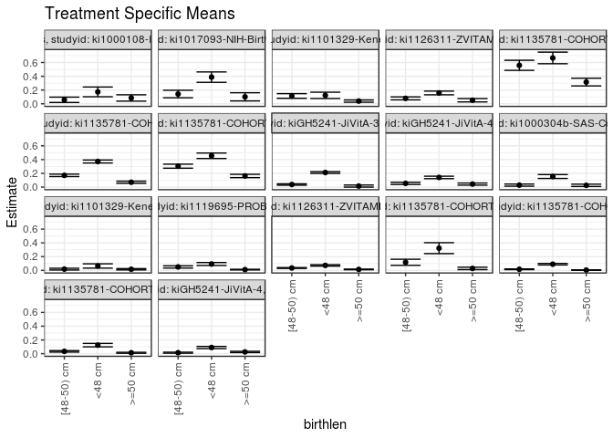

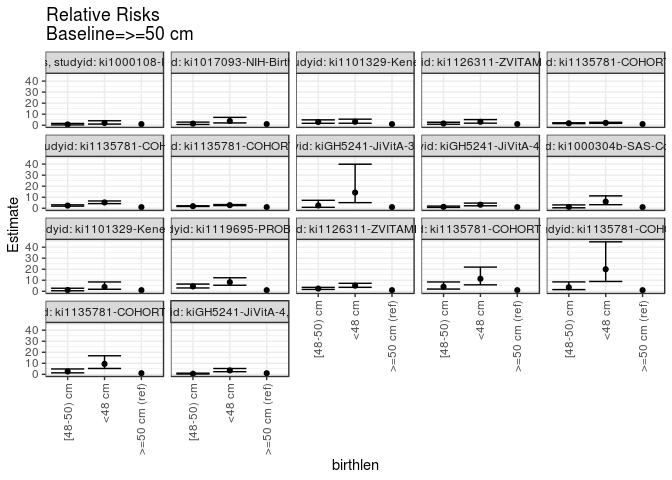

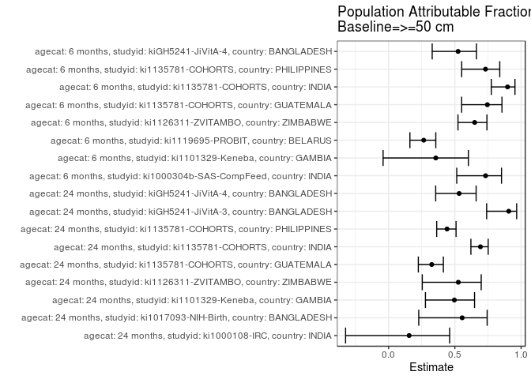

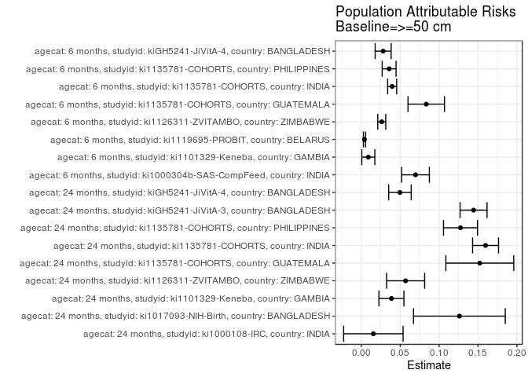

## Results Table

### Parameter: TSM

| agecat | studyid | country | intervention_level | baseline_level | estimate | ci_lower | ci_upper |
| --- | --- | --- | --- | --- | --- | --- | --- |
| 6 months | ki1000304b-SAS-CompFeed | INDIA | >=50 cm | NA | 0.0255102 | 0.0084713 | 0.0425492 |
| 6 months | ki1000304b-SAS-CompFeed | INDIA | <48 cm | NA | 0.1537377 | 0.1251875 | 0.1822879 |
| 6 months | ki1000304b-SAS-CompFeed | INDIA | [48-50) cm | NA | 0.0286396 | 0.0129545 | 0.0443247 |
| 6 months | ki1101329-Keneba | GAMBIA | >=50 cm | NA | 0.0162482 | 0.0067211 | 0.0257752 |
| 6 months | ki1101329-Keneba | GAMBIA | <48 cm | NA | 0.0641026 | 0.0327081 | 0.0954970 |
| 6 months | ki1101329-Keneba | GAMBIA | [48-50) cm | NA | 0.0183486 | 0.0057464 | 0.0309508 |
| 6 months | ki1119695-PROBIT | BELARUS | >=50 cm | NA | 0.0113318 | 0.0063909 | 0.0162728 |
| 6 months | ki1119695-PROBIT | BELARUS | <48 cm | NA | 0.0930233 | 0.0715043 | 0.1145422 |
| 6 months | ki1119695-PROBIT | BELARUS | [48-50) cm | NA | 0.0502707 | 0.0337764 | 0.0667650 |
| 6 months | ki1126311-ZVITAMBO | ZIMBABWE | >=50 cm | NA | 0.0141844 | 0.0095836 | 0.0187852 |
| 6 months | ki1126311-ZVITAMBO | ZIMBABWE | <48 cm | NA | 0.0723881 | 0.0625768 | 0.0821993 |
| 6 months | ki1126311-ZVITAMBO | ZIMBABWE | [48-50) cm | NA | 0.0348318 | 0.0286309 | 0.0410327 |
| 6 months | ki1135781-COHORTS | GUATEMALA | >=50 cm | NA | 0.0284900 | 0.0110727 | 0.0459073 |
| 6 months | ki1135781-COHORTS | GUATEMALA | <48 cm | NA | 0.3233083 | 0.2437579 | 0.4028586 |
| 6 months | ki1135781-COHORTS | GUATEMALA | [48-50) cm | NA | 0.1176471 | 0.0734024 | 0.1618917 |
| 6 months | ki1135781-COHORTS | INDIA | >=50 cm | NA | 0.0045113 | 0.0009094 | 0.0081131 |
| 6 months | ki1135781-COHORTS | INDIA | <48 cm | NA | 0.0901186 | 0.0789596 | 0.1012775 |
| 6 months | ki1135781-COHORTS | INDIA | [48-50) cm | NA | 0.0162637 | 0.0110657 | 0.0214618 |
| 6 months | ki1135781-COHORTS | PHILIPPINES | >=50 cm | NA | 0.0131313 | 0.0060389 | 0.0202237 |
| 6 months | ki1135781-COHORTS | PHILIPPINES | <48 cm | NA | 0.1240768 | 0.0992390 | 0.1489146 |
| 6 months | ki1135781-COHORTS | PHILIPPINES | [48-50) cm | NA | 0.0338491 | 0.0228245 | 0.0448738 |
| 6 months | kiGH5241-JiVitA-4 | BANGLADESH | >=50 cm | NA | 0.0254314 | 0.0162510 | 0.0346118 |
| 6 months | kiGH5241-JiVitA-4 | BANGLADESH | <48 cm | NA | 0.0899636 | 0.0740404 | 0.1058868 |
| 6 months | kiGH5241-JiVitA-4 | BANGLADESH | [48-50) cm | NA | 0.0140562 | 0.0066198 | 0.0214927 |
| 24 months | ki1000108-IRC | INDIA | >=50 cm | NA | 0.0845070 | 0.0386997 | 0.1303144 |
| 24 months | ki1000108-IRC | INDIA | <48 cm | NA | 0.1727273 | 0.1019956 | 0.2434590 |
| 24 months | ki1000108-IRC | INDIA | [48-50) cm | NA | 0.0579710 | 0.0189316 | 0.0970105 |
| 24 months | ki1017093-NIH-Birth | BANGLADESH | >=50 cm | NA | 0.1010101 | 0.0415788 | 0.1604414 |
| 24 months | ki1017093-NIH-Birth | BANGLADESH | <48 cm | NA | 0.3875000 | 0.3119208 | 0.4630792 |
| 24 months | ki1017093-NIH-Birth | BANGLADESH | [48-50) cm | NA | 0.1419355 | 0.0869291 | 0.1969418 |
| 24 months | ki1101329-Keneba | GAMBIA | >=50 cm | NA | 0.0392523 | 0.0227892 | 0.0557155 |
| 24 months | ki1101329-Keneba | GAMBIA | <48 cm | NA | 0.1224490 | 0.0765358 | 0.1683622 |
| 24 months | ki1101329-Keneba | GAMBIA | [48-50) cm | NA | 0.1137725 | 0.0797026 | 0.1478423 |
| 24 months | ki1126311-ZVITAMBO | ZIMBABWE | >=50 cm | NA | 0.0512821 | 0.0267995 | 0.0757646 |
| 24 months | ki1126311-ZVITAMBO | ZIMBABWE | <48 cm | NA | 0.1575246 | 0.1307390 | 0.1843102 |
| 24 months | ki1126311-ZVITAMBO | ZIMBABWE | [48-50) cm | NA | 0.0786325 | 0.0568141 | 0.1004509 |
| 24 months | ki1135781-COHORTS | GUATEMALA | >=50 cm | NA | 0.3155894 | 0.2593710 | 0.3718077 |
| 24 months | ki1135781-COHORTS | GUATEMALA | <48 cm | NA | 0.6666667 | 0.5822478 | 0.7510855 |
| 24 months | ki1135781-COHORTS | GUATEMALA | [48-50) cm | NA | 0.5593220 | 0.4861170 | 0.6325271 |
| 24 months | ki1135781-COHORTS | INDIA | >=50 cm | NA | 0.0706781 | 0.0551526 | 0.0862036 |
| 24 months | ki1135781-COHORTS | INDIA | <48 cm | NA | 0.3717684 | 0.3502276 | 0.3933091 |
| 24 months | ki1135781-COHORTS | INDIA | [48-50) cm | NA | 0.1705121 | 0.1530244 | 0.1879998 |
| 24 months | ki1135781-COHORTS | PHILIPPINES | >=50 cm | NA | 0.1616499 | 0.1375541 | 0.1857457 |
| 24 months | ki1135781-COHORTS | PHILIPPINES | <48 cm | NA | 0.4552980 | 0.4155747 | 0.4950214 |
| 24 months | ki1135781-COHORTS | PHILIPPINES | [48-50) cm | NA | 0.3039320 | 0.2745382 | 0.3333258 |
| 24 months | kiGH5241-JiVitA-3 | BANGLADESH | >=50 cm | NA | 0.0148515 | -0.0004421 | 0.0301450 |
| 24 months | kiGH5241-JiVitA-3 | BANGLADESH | <48 cm | NA | 0.2117624 | 0.1987696 | 0.2247552 |
| 24 months | kiGH5241-JiVitA-3 | BANGLADESH | [48-50) cm | NA | 0.0373614 | 0.0276804 | 0.0470423 |
| 24 months | kiGH5241-JiVitA-4 | BANGLADESH | >=50 cm | NA | 0.0436397 | 0.0283323 | 0.0589472 |
| 24 months | kiGH5241-JiVitA-4 | BANGLADESH | <48 cm | NA | 0.1404321 | 0.1228982 | 0.1579660 |
| 24 months | kiGH5241-JiVitA-4 | BANGLADESH | [48-50) cm | NA | 0.0538302 | 0.0376008 | 0.0700596 |

### Parameter: E(Y)

| agecat | studyid | country | intervention_level | baseline_level | estimate | ci_lower | ci_upper |
| --- | --- | --- | --- | --- | --- | --- | --- |
| 6 months | ki1000304b-SAS-CompFeed | INDIA | NA | NA | 0.0951662 | 0.0766361 | 0.1136962 |
| 6 months | ki1101329-Keneba | GAMBIA | NA | NA | 0.0252413 | 0.0168616 | 0.0336210 |
| 6 months | ki1119695-PROBIT | BELARUS | NA | NA | 0.0154178 | 0.0100323 | 0.0208033 |
| 6 months | ki1126311-ZVITAMBO | ZIMBABWE | NA | NA | 0.0404570 | 0.0362870 | 0.0446270 |
| 6 months | ki1135781-COHORTS | GUATEMALA | NA | NA | 0.1119186 | 0.0883438 | 0.1354934 |
| 6 months | ki1135781-COHORTS | INDIA | NA | NA | 0.0441728 | 0.0390306 | 0.0493149 |
| 6 months | ki1135781-COHORTS | PHILIPPINES | NA | NA | 0.0488708 | 0.0407385 | 0.0570030 |
| 6 months | kiGH5241-JiVitA-4 | BANGLADESH | NA | NA | 0.0534826 | 0.0450763 | 0.0618888 |
| 24 months | ki1000108-IRC | INDIA | NA | NA | 0.1000000 | 0.0701878 | 0.1298122 |
| 24 months | ki1017093-NIH-Birth | BANGLADESH | NA | NA | 0.2270531 | 0.1866503 | 0.2674560 |
| 24 months | ki1101329-Keneba | GAMBIA | NA | NA | 0.0779343 | 0.0618270 | 0.0940416 |
| 24 months | ki1126311-ZVITAMBO | ZIMBABWE | NA | NA | 0.1082090 | 0.0930209 | 0.1233971 |
| 24 months | ki1135781-COHORTS | GUATEMALA | NA | NA | 0.4678571 | 0.4264941 | 0.5092202 |
| 24 months | ki1135781-COHORTS | INDIA | NA | NA | 0.2303489 | 0.2183836 | 0.2423141 |
| 24 months | ki1135781-COHORTS | PHILIPPINES | NA | NA | 0.2891073 | 0.2711229 | 0.3070917 |
| 24 months | kiGH5241-JiVitA-3 | BANGLADESH | NA | NA | 0.1591036 | 0.1492688 | 0.1689383 |
| 24 months | kiGH5241-JiVitA-4 | BANGLADESH | NA | NA | 0.0933032 | 0.0829251 | 0.1036813 |

### Parameter: RR

| agecat | studyid | country | intervention_level | baseline_level | estimate | ci_lower | ci_upper |
| --- | --- | --- | --- | --- | --- | --- | --- |
| 6 months | ki1000304b-SAS-CompFeed | INDIA | >=50 cm | >=50 cm | 1.0000000 | 1.0000000 | 1.000000 |
| 6 months | ki1000304b-SAS-CompFeed | INDIA | <48 cm | >=50 cm | 6.0265162 | 3.2342085 | 11.229609 |
| 6 months | ki1000304b-SAS-CompFeed | INDIA | [48-50) cm | >=50 cm | 1.1226730 | 0.4128721 | 3.052748 |
| 6 months | ki1101329-Keneba | GAMBIA | >=50 cm | >=50 cm | 1.0000000 | 1.0000000 | 1.000000 |
| 6 months | ki1101329-Keneba | GAMBIA | <48 cm | >=50 cm | 3.9452214 | 1.8377214 | 8.469604 |
| 6 months | ki1101329-Keneba | GAMBIA | [48-50) cm | >=50 cm | 1.1292744 | 0.4577236 | 2.786093 |
| 6 months | ki1119695-PROBIT | BELARUS | >=50 cm | >=50 cm | 1.0000000 | 1.0000000 | 1.000000 |
| 6 months | ki1119695-PROBIT | BELARUS | <48 cm | >=50 cm | 8.2090152 | 5.5059079 | 12.239204 |
| 6 months | ki1119695-PROBIT | BELARUS | [48-50) cm | >=50 cm | 4.4362331 | 3.0055082 | 6.548032 |
| 6 months | ki1126311-ZVITAMBO | ZIMBABWE | >=50 cm | >=50 cm | 1.0000000 | 1.0000000 | 1.000000 |
| 6 months | ki1126311-ZVITAMBO | ZIMBABWE | <48 cm | >=50 cm | 5.1033582 | 3.5907642 | 7.253126 |
| 6 months | ki1126311-ZVITAMBO | ZIMBABWE | [48-50) cm | >=50 cm | 2.4556416 | 1.6961984 | 3.555112 |
| 6 months | ki1135781-COHORTS | GUATEMALA | >=50 cm | >=50 cm | 1.0000000 | 1.0000000 | 1.000000 |
| 6 months | ki1135781-COHORTS | GUATEMALA | <48 cm | >=50 cm | 11.3481203 | 5.8711376 | 21.934392 |
| 6 months | ki1135781-COHORTS | GUATEMALA | [48-50) cm | >=50 cm | 4.1294118 | 2.0145065 | 8.464625 |
| 6 months | ki1135781-COHORTS | INDIA | >=50 cm | >=50 cm | 1.0000000 | 1.0000000 | 1.000000 |
| 6 months | ki1135781-COHORTS | INDIA | <48 cm | >=50 cm | 19.9762846 | 8.9048026 | 44.813115 |
| 6 months | ki1135781-COHORTS | INDIA | [48-50) cm | >=50 cm | 3.6051282 | 1.5255447 | 8.519547 |
| 6 months | ki1135781-COHORTS | PHILIPPINES | >=50 cm | >=50 cm | 1.0000000 | 1.0000000 | 1.000000 |
| 6 months | ki1135781-COHORTS | PHILIPPINES | <48 cm | >=50 cm | 9.4489263 | 5.3115465 | 16.809080 |
| 6 months | ki1135781-COHORTS | PHILIPPINES | [48-50) cm | >=50 cm | 2.5777414 | 1.3718991 | 4.843469 |
| 6 months | kiGH5241-JiVitA-4 | BANGLADESH | >=50 cm | >=50 cm | 1.0000000 | 1.0000000 | 1.000000 |
| 6 months | kiGH5241-JiVitA-4 | BANGLADESH | <48 cm | >=50 cm | 3.5374972 | 2.3727885 | 5.273916 |
| 6 months | kiGH5241-JiVitA-4 | BANGLADESH | [48-50) cm | >=50 cm | 0.5527108 | 0.2895371 | 1.055095 |
| 24 months | ki1000108-IRC | INDIA | >=50 cm | >=50 cm | 1.0000000 | 1.0000000 | 1.000000 |
| 24 months | ki1000108-IRC | INDIA | <48 cm | >=50 cm | 2.0439394 | 1.0361710 | 4.031852 |
| 24 months | ki1000108-IRC | INDIA | [48-50) cm | >=50 cm | 0.6859903 | 0.2889866 | 1.628389 |
| 24 months | ki1017093-NIH-Birth | BANGLADESH | >=50 cm | >=50 cm | 1.0000000 | 1.0000000 | 1.000000 |
| 24 months | ki1017093-NIH-Birth | BANGLADESH | <48 cm | >=50 cm | 3.8362500 | 2.0639869 | 7.130284 |
| 24 months | ki1017093-NIH-Birth | BANGLADESH | [48-50) cm | >=50 cm | 1.4051613 | 0.6946248 | 2.842511 |
| 24 months | ki1101329-Keneba | GAMBIA | >=50 cm | >=50 cm | 1.0000000 | 1.0000000 | 1.000000 |
| 24 months | ki1101329-Keneba | GAMBIA | <48 cm | >=50 cm | 3.1195335 | 1.7773006 | 5.475432 |
| 24 months | ki1101329-Keneba | GAMBIA | [48-50) cm | >=50 cm | 2.8984887 | 1.7312432 | 4.852719 |
| 24 months | ki1126311-ZVITAMBO | ZIMBABWE | >=50 cm | >=50 cm | 1.0000000 | 1.0000000 | 1.000000 |
| 24 months | ki1126311-ZVITAMBO | ZIMBABWE | <48 cm | >=50 cm | 3.0717299 | 1.8504940 | 5.098922 |
| 24 months | ki1126311-ZVITAMBO | ZIMBABWE | [48-50) cm | >=50 cm | 1.5333333 | 0.8827227 | 2.663476 |
| 24 months | ki1135781-COHORTS | GUATEMALA | >=50 cm | >=50 cm | 1.0000000 | 1.0000000 | 1.000000 |
| 24 months | ki1135781-COHORTS | GUATEMALA | <48 cm | >=50 cm | 2.1124498 | 1.6977266 | 2.628482 |
| 24 months | ki1135781-COHORTS | GUATEMALA | [48-50) cm | >=50 cm | 1.7723096 | 1.4208193 | 2.210754 |
| 24 months | ki1135781-COHORTS | INDIA | >=50 cm | >=50 cm | 1.0000000 | 1.0000000 | 1.000000 |
| 24 months | ki1135781-COHORTS | INDIA | <48 cm | >=50 cm | 5.2600198 | 4.1910722 | 6.601606 |
| 24 months | ki1135781-COHORTS | INDIA | [48-50) cm | >=50 cm | 2.4125158 | 1.8931503 | 3.074364 |
| 24 months | ki1135781-COHORTS | PHILIPPINES | >=50 cm | >=50 cm | 1.0000000 | 1.0000000 | 1.000000 |
| 24 months | ki1135781-COHORTS | PHILIPPINES | <48 cm | >=50 cm | 2.8165677 | 2.3697901 | 3.347577 |
| 24 months | ki1135781-COHORTS | PHILIPPINES | [48-50) cm | >=50 cm | 1.8801862 | 1.5741007 | 2.245790 |
| 24 months | kiGH5241-JiVitA-3 | BANGLADESH | >=50 cm | >=50 cm | 1.0000000 | 1.0000000 | 1.000000 |
| 24 months | kiGH5241-JiVitA-3 | BANGLADESH | <48 cm | >=50 cm | 14.2586623 | 5.0919529 | 39.927599 |
| 24 months | kiGH5241-JiVitA-3 | BANGLADESH | [48-50) cm | >=50 cm | 2.5156637 | 0.8759202 | 7.225046 |
| 24 months | kiGH5241-JiVitA-4 | BANGLADESH | >=50 cm | >=50 cm | 1.0000000 | 1.0000000 | 1.000000 |
| 24 months | kiGH5241-JiVitA-4 | BANGLADESH | <48 cm | >=50 cm | 3.2179865 | 2.2232727 | 4.657745 |
| 24 months | kiGH5241-JiVitA-4 | BANGLADESH | [48-50) cm | >=50 cm | 1.2335139 | 0.7735872 | 1.966884 |

### Parameter: PAR

| agecat | studyid | country | intervention_level | baseline_level | estimate | ci_lower | ci_upper |
| --- | --- | --- | --- | --- | --- | --- | --- |
| 6 months | ki1000304b-SAS-CompFeed | INDIA | >=50 cm | NA | 0.0696560 | 0.0518817 | 0.0874302 |
| 6 months | ki1101329-Keneba | GAMBIA | >=50 cm | NA | 0.0089931 | 0.0006416 | 0.0173447 |
| 6 months | ki1119695-PROBIT | BELARUS | >=50 cm | NA | 0.0040860 | 0.0026878 | 0.0054842 |
| 6 months | ki1126311-ZVITAMBO | ZIMBABWE | >=50 cm | NA | 0.0262726 | 0.0211708 | 0.0313745 |
| 6 months | ki1135781-COHORTS | GUATEMALA | >=50 cm | NA | 0.0834286 | 0.0599851 | 0.1068720 |
| 6 months | ki1135781-COHORTS | INDIA | >=50 cm | NA | 0.0396615 | 0.0338486 | 0.0454744 |
| 6 months | ki1135781-COHORTS | PHILIPPINES | >=50 cm | NA | 0.0357395 | 0.0268198 | 0.0446592 |
| 6 months | kiGH5241-JiVitA-4 | BANGLADESH | >=50 cm | NA | 0.0280512 | 0.0177879 | 0.0383145 |
| 24 months | ki1000108-IRC | INDIA | >=50 cm | NA | 0.0154930 | -0.0227050 | 0.0536909 |
| 24 months | ki1017093-NIH-Birth | BANGLADESH | >=50 cm | NA | 0.1260430 | 0.0670921 | 0.1849940 |
| 24 months | ki1101329-Keneba | GAMBIA | >=50 cm | NA | 0.0386819 | 0.0226142 | 0.0547497 |
| 24 months | ki1126311-ZVITAMBO | ZIMBABWE | >=50 cm | NA | 0.0569269 | 0.0324836 | 0.0813702 |
| 24 months | ki1135781-COHORTS | GUATEMALA | >=50 cm | NA | 0.1522678 | 0.1086468 | 0.1958888 |
| 24 months | ki1135781-COHORTS | INDIA | >=50 cm | NA | 0.1596708 | 0.1429936 | 0.1763479 |
| 24 months | ki1135781-COHORTS | PHILIPPINES | >=50 cm | NA | 0.1274573 | 0.1056054 | 0.1493093 |
| 24 months | kiGH5241-JiVitA-3 | BANGLADESH | >=50 cm | NA | 0.1442521 | 0.1269500 | 0.1615542 |
| 24 months | kiGH5241-JiVitA-4 | BANGLADESH | >=50 cm | NA | 0.0496635 | 0.0351996 | 0.0641274 |

### Parameter: PAF

| agecat | studyid | country | intervention_level | baseline_level | estimate | ci_lower | ci_upper |
| --- | --- | --- | --- | --- | --- | --- | --- |
| 6 months | ki1000304b-SAS-CompFeed | INDIA | >=50 cm | NA | 0.7319404 | 0.5143576 | 0.8520394 |
| 6 months | ki1101329-Keneba | GAMBIA | >=50 cm | NA | 0.3562864 | -0.0415418 | 0.6021598 |
| 6 months | ki1119695-PROBIT | BELARUS | >=50 cm | NA | 0.2650159 | 0.1608133 | 0.3562795 |
| 6 months | ki1126311-ZVITAMBO | ZIMBABWE | >=50 cm | NA | 0.6493960 | 0.5236028 | 0.7419734 |
| 6 months | ki1135781-COHORTS | GUATEMALA | >=50 cm | NA | 0.7454397 | 0.5513963 | 0.8555497 |
| 6 months | ki1135781-COHORTS | INDIA | >=50 cm | NA | 0.8978720 | 0.7751591 | 0.9536111 |
| 6 months | ki1135781-COHORTS | PHILIPPINES | >=50 cm | NA | 0.7313055 | 0.5517329 | 0.8389426 |
| 6 months | kiGH5241-JiVitA-4 | BANGLADESH | >=50 cm | NA | 0.5244915 | 0.3290569 | 0.6629992 |
| 24 months | ki1000108-IRC | INDIA | >=50 cm | NA | 0.1549296 | -0.3244291 | 0.4607910 |
| 24 months | ki1017093-NIH-Birth | BANGLADESH | >=50 cm | NA | 0.5551257 | 0.2277375 | 0.7437230 |
| 24 months | ki1101329-Keneba | GAMBIA | >=50 cm | NA | 0.4963405 | 0.2780782 | 0.6486144 |
| 24 months | ki1126311-ZVITAMBO | ZIMBABWE | >=50 cm | NA | 0.5260831 | 0.2541095 | 0.6988872 |
| 24 months | ki1135781-COHORTS | GUATEMALA | >=50 cm | NA | 0.3254579 | 0.2245259 | 0.4132530 |
| 24 months | ki1135781-COHORTS | INDIA | >=50 cm | NA | 0.6931692 | 0.6211681 | 0.7514857 |
| 24 months | ki1135781-COHORTS | PHILIPPINES | >=50 cm | NA | 0.4408652 | 0.3630895 | 0.5091434 |
| 24 months | kiGH5241-JiVitA-3 | BANGLADESH | >=50 cm | NA | 0.9066552 | 0.7397900 | 0.9665145 |
| 24 months | kiGH5241-JiVitA-4 | BANGLADESH | >=50 cm | NA | 0.5322805 | 0.3554973 | 0.6605732 |